# ENV 790.30 - Time Series Analysis for Energy Data | Spring 2023

Assignment 2 - Due date 02/03/23

Kassie Huang

## Submission Instructions

You should open the .rmd file corresponding to this assignment on RStudio. The file is available on our class repository on Github.

Once you have the file open on your local machine the first thing you will do is rename the file such that it includes your first and last name (e.g., “LuanaLima_TSA_A02_Sp23.Rmd”). Then change “Student Name” on line 4 with your name.

Then you will start working through the assignment by **creating code and output** that answer each question. Be sure to use this assignment document. Your report should contain the answer to each question and any plots/tables you obtained (when applicable).

When you have completed the assignment, **Knit** the text and code into a single PDF file. Submit this pdf using Sakai.

## R packages

R packages needed for this assignment:“forecast”,“tseries”, and “dplyr”. Install these packages, if you haven’t done yet. Do not forget to load them before running your script, since they are NOT default packages.\

```r
#Load/install required package here
library(forecast)
library(tseries)
library(dplyr)
```

## Data set information

Consider the data provided in the spreadsheet “Table_10.1_Renewable_Energy_Production_and_Consumption_by_Source.xlsx” on our **Data** folder. The data comes from the US Energy Information and Administration and corresponds to the December 2022 Monthly Energy Review. The spreadsheet is ready to be used. You will also find a $.csv$ version of the data “Table_10.1_Renewable_Energy_Production_and_Consumption_by_Source-Edit.csv”. You may use the function $read.table()$ to import the $.csv$ data in R. Or refer to the file “M2_ImportingData_CSV_XLSX.Rmd” in our Lessons folder for functions that are better suited for importing the $.xlsx$.

```r
#Importing data set
library(readxl)
energy_data <- read_excel(path='./Data/Table_10.1_Renewable_Energy_Production_and_Consumption_by_Source.xlsx',sheet=1,skip=12,col_names=FALSE)
colnames(energy_data) <- read_excel(path='./Data/Table_10.1_Renewable_Energy_Production_and_Consumption_by_Source.xlsx',sheet=1, skip=10, n_max=1, col_names=FALSE)
head(energy_data)
```

| Month | Wood Energy Production | Biofuels Production | Total Biomass Energy Production | Total Renewable Energy Production | Hydroelectric Power Consumption | Geothermal Energy Consumption | Solar Energy Consumption | Wind Energy Consumption | Wood Energy Consumption | Waste Energy Consumption | Biofuels Consumption | Total Biomass Energy Consumption | Total Renewable Energy Consumption |
| --- | --- | --- | --- | --- | --- | --- | --- | --- | --- | --- | --- | --- | --- |
| 1973-01-01 | 129.630 | Not Available | 129.787 | 403.981 | 272.703 | 1.491 | Not Available | Not Available | 129.630 | 0.157 | Not Available | 129.787 | 403.981 |
| 1973-02-01 | 117.194 | Not Available | 117.338 | 360.900 | 242.199 | 1.363 | Not Available | Not Available | 117.194 | 0.144 | Not Available | 117.338 | 360.900 |
| 1973-03-01 | 129.763 | Not Available | 129.938 | 400.161 | 268.810 | 1.412 | Not Available | Not Available | 129.763 | 0.176 | Not Available | 129.938 | 400.161 |
| 1973-04-01 | 125.462 | Not Available | 125.636 | 380.470 | 253.185 | 1.649 | Not Available | Not Available | 125.462 | 0.174 | Not Available | 125.636 | 380.470 |
| 1973-05-01 | 129.624 | Not Available | 129.834 | 392.141 | 260.770 | 1.537 | Not Available | Not Available | 129.624 | 0.210 | Not Available | 129.834 | 392.141 |
| 1973-06-01 | 125.435 | Not Available | 125.611 | 377.232 | 249.859 | 1.763 | Not Available | Not Available | 125.435 | 0.176 | Not Available | 125.611 | 377.232 |

## Question 1

You will work only with the following columns: Total Biomass Energy Production, Total Renewable Energy Production, Hydroelectric Power Consumption. Create a data frame structure with these three time series only. Use the command head() to verify your data.

```r
energy_data2 <- as.data.frame(energy_data[,4:6])
head(energy_data2)
```

|  | Total Biomass Energy Production | Total Renewable Energy Production | Hydroelectric Power Consumption |
| --- | --- | --- | --- |
| 1 | 129.787 | 403.981 | 272.703 |
| 2 | 117.338 | 360.900 | 242.199 |
| 3 | 129.938 | 400.161 | 268.810 |
| 4 | 125.636 | 380.470 | 253.185 |
| 5 | 129.834 | 392.141 | 260.770 |
| 6 | 125.611 | 377.232 | 249.859 |

## Question 2

Transform your data frame in a time series object and specify the starting point and frequency of the time series using the function ts().

```r
ts_energy_data2 <- ts(energy_data2,start = c(1973,1), frequency = 12)

#check the incomplete 2022 data are correctly imported
tail(ts_energy_data2,10)
```

```
##          Total Biomass Energy Production Total Renewable Energy Production
## Dec 2021                         455.075                          1118.251
## Jan 2022                         436.735                          1130.434
## Feb 2022                         397.763                          1071.921
## Mar 2022                         431.900                          1209.837
## Apr 2022                         406.080                          1176.084
## May 2022                         434.982                          1219.656
## Jun 2022                         434.199                          1187.064
## Jul 2022                         440.585                          1132.137
## Aug 2022                         431.969                          1043.955
## Sep 2022                         398.696                           976.813
##          Hydroelectric Power Consumption
## Dec 2021                         208.358
## Jan 2022                         232.468
## Feb 2022                         203.135
## Mar 2022                         225.165
## Apr 2022                         172.956
## May 2022                         204.198
## Jun 2022                         237.735
## Jul 2022                         213.172
## Aug 2022                         191.155
## Sep 2022                         148.808
```

## Question 3

Compute mean and standard deviation for these three series.

```r
#create empty vectors to store means and SDs
means <- c()
SDs <- c()
#index for the loop
ndata <- ncol(energy_data2)

for(i in 1:ndata){
  means <- c(means,mean(energy_data2[,i]))
  SDs <- c(SDs,sd(energy_data2[,i]))
}
```

## Question 4

Display and interpret the time series plot for each of these variables. Try to make your plot as informative as possible by writing titles, labels, etc. For each plot add a horizontal line at the mean of each series in a different color.

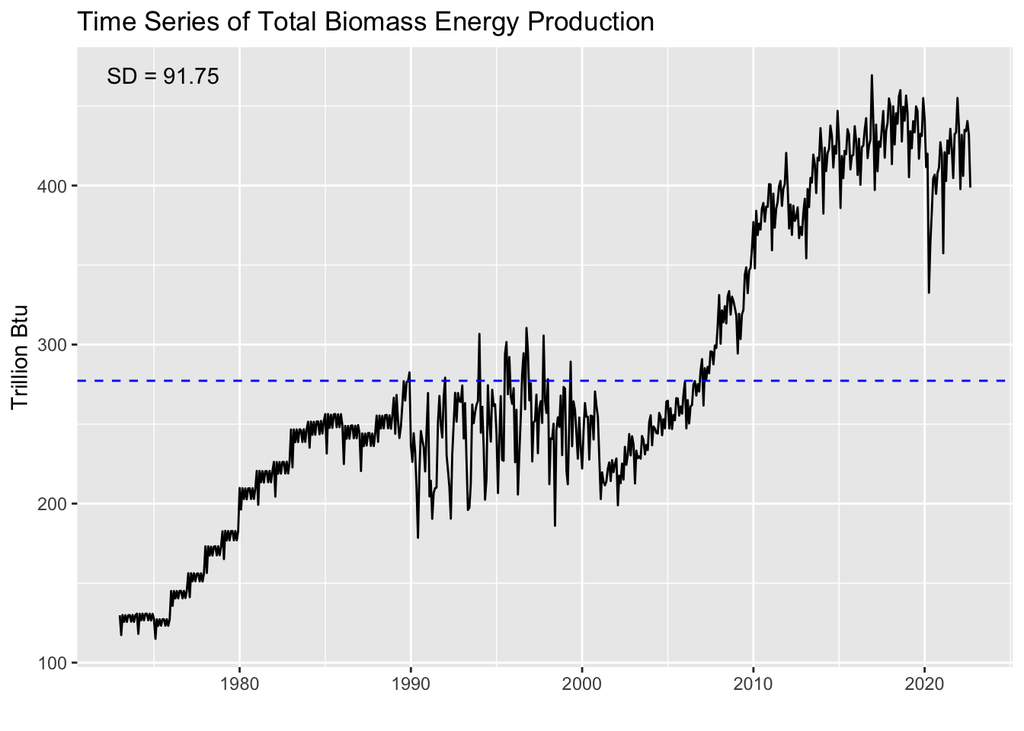

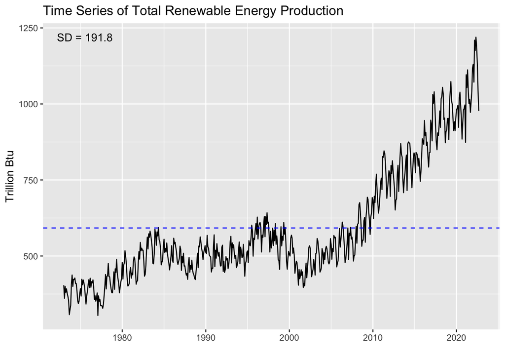

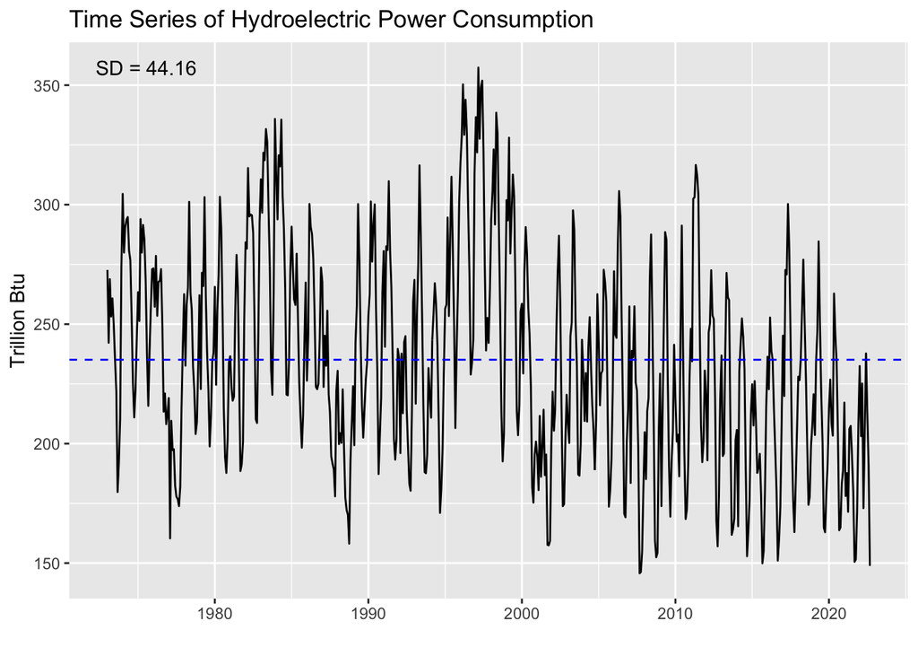

```r
#installed ggfortify previously in console following
#http://www.sthda.com/english/wiki/ggfortify-extension-to-ggplot2-to-handle-some-popular-packages-r-software-and-data-visualization#installation

library(ggfortify)
library(lubridate)
datanames <- colnames(energy_data2)

for(i in 1:ndata){
  print(autoplot(ts_energy_data2[,i])+
          geom_hline(yintercept = means[i],linetype="dashed",color='blue')+
          labs(title = paste('Time Series of',datanames[i],sep=' '),
               y='Trillion Btu')+
        annotate("text", x=as_date(2020) ,y = max(ts_energy_data2[,i]), label = paste("SD =",round(SDs[i],2),sep=' ')))
}
```

The time series plot of the total biomass energy production showed a non-linear increase trend. The pre-1990 data show some subtle seasonality with a more pronounced valley and several smaller waveform, while the post-1990 data become more volatile and it is difficult to observe any seasonality. The time series plot of the total renewable energy production showed a non-linear increase trend. There may also be some seasonal components in this data series, which may be related to the seasonality of sunlight and wind energy, but it’s not clear in looking the plot. The time series plot of the hydroelectric power consumption didn’t show a clear trend and it is dominated by strong seasonal patterns.

## Question 5

Compute the correlation between these three series. Are they significantly correlated? Explain your answer.

```r
#Total Biomass Energy Production ~ Renewable Energy Production
cor_Biomass_Renew <- lm(`Total Biomass Energy Production`~`Total Renewable Energy Production`,data=energy_data2)
summary(cor_Biomass_Renew)
```

```
##
## Call:
## lm(formula = `Total Biomass Energy Production` ~ `Total Renewable Energy Production`,
##     data = energy_data2)
##
## Residuals:
##      Min       1Q   Median       3Q      Max
## -127.775  -23.753    3.474   26.182   79.099
##
## Coefficients:
##                                      Estimate Std. Error t value Pr(>|t|)
## (Intercept)                         17.032186   4.823999   3.531 0.000446 ***
## `Total Renewable Energy Production`  0.439444   0.007751  56.697  < 2e-16 ***
## ---
## Signif. codes:  0 '***' 0.001 '**' 0.01 '*' 0.05 '.' 0.1 ' ' 1
##
## Residual standard error: 36.29 on 595 degrees of freedom
## Multiple R-squared:  0.8438, Adjusted R-squared:  0.8436
## F-statistic:  3215 on 1 and 595 DF,  p-value: < 2.2e-16
```

The P-value is 2.2e-16, which is less than 0.001, indicating that the total renewable energy production is significantly correlated with the total biomass energy production. Meanwhile, the coefficient is equal to 0.44, which is greater than 0, indicating that the total renewable energy production is positively correlated with the biomass energy production.

```r
#Total Renewable energy production ~ Hydroelectric Power Consumption
cor_Renew_Hydro <- lm(`Total Renewable Energy Production`~`Hydroelectric Power Consumption`,data=energy_data2)
summary(cor_Renew_Hydro)
```

```
##
## Call:
## lm(formula = `Total Renewable Energy Production` ~ `Hydroelectric Power Consumption`,
##     data = energy_data2)
##
## Residuals:
##     Min      1Q  Median      3Q     Max
## -320.18 -138.68  -56.52   85.59  614.13
##
## Coefficients:
##                                   Estimate Std. Error t value Pr(>|t|)
## (Intercept)                       693.8506    42.3815  16.372   <2e-16 ***
## `Hydroelectric Power Consumption`  -0.4325     0.1772  -2.441   0.0149 *
## ---
## Signif. codes:  0 '***' 0.001 '**' 0.01 '*' 0.05 '.' 0.1 ' ' 1
##
## Residual standard error: 191 on 595 degrees of freedom
## Multiple R-squared:  0.009918,   Adjusted R-squared:  0.008254
## F-statistic:  5.96 on 1 and 595 DF,  p-value: 0.01492
```

```r
#Total Biomass Energy Production ~ Hydroelectric Power Consumption
cor_Biomass_Hydro <- lm(`Total Biomass Energy Production`~`Hydroelectric Power Consumption`,data=energy_data2)
summary(cor_Biomass_Hydro)
```

```
##
## Call:
## lm(formula = `Total Biomass Energy Production` ~ `Hydroelectric Power Consumption`,
##     data = energy_data2)
##
## Residuals:
##     Min      1Q  Median      3Q     Max
## -185.97  -56.43  -15.37   62.30  194.26
##
## Coefficients:
##                                    Estimate Std. Error t value Pr(>|t|)
## (Intercept)                       423.71401   19.43869  21.797  < 2e-16 ***
## `Hydroelectric Power Consumption`  -0.62294    0.08126  -7.666 7.26e-14 ***
## ---
## Signif. codes:  0 '***' 0.001 '**' 0.01 '*' 0.05 '.' 0.1 ' ' 1
##
## Residual standard error: 87.61 on 595 degrees of freedom
## Multiple R-squared:  0.08989,    Adjusted R-squared:  0.08836
## F-statistic: 58.77 on 1 and 595 DF,  p-value: 7.256e-14
```

## Question 6

Compute the autocorrelation function from lag 1 up to lag 40 for these three variables. What can you say about these plots? Do the three of them have the same behavior?

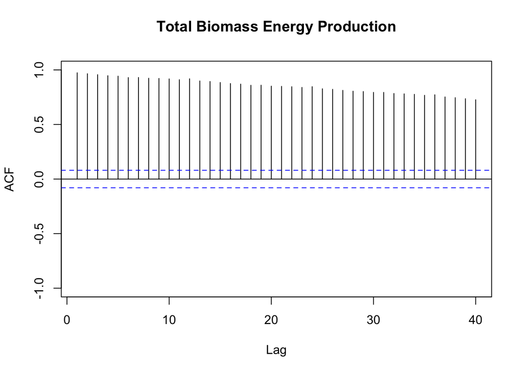

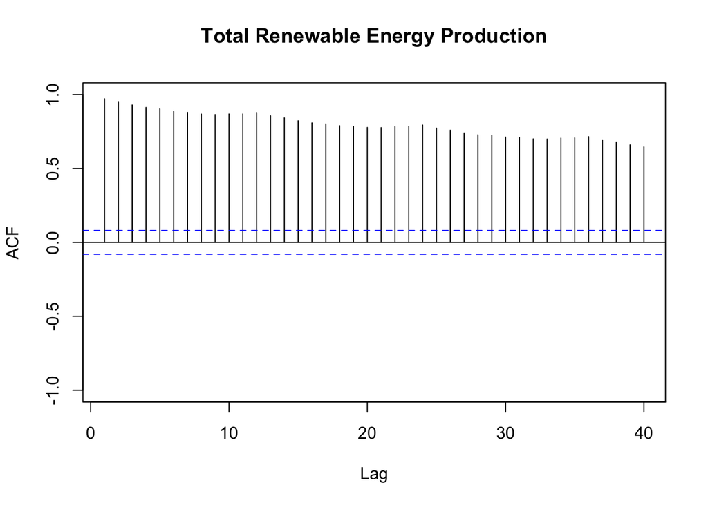

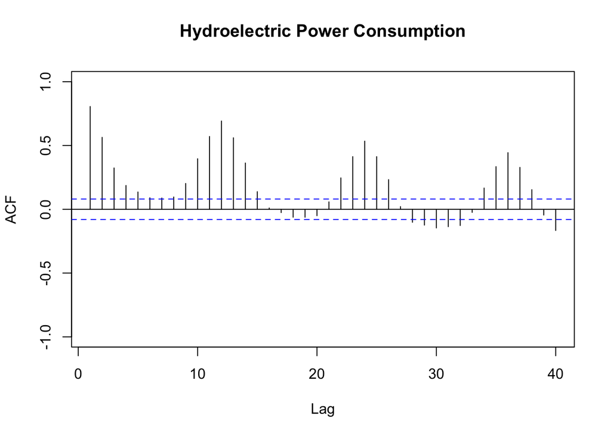

```r
for(i in 1:ndata){
  Acf(energy_data2[,i],lag.max = 40,main=datanames[i],ylim=c(-1,1))
}
```

From the ACF plot of the total biomass energy production, this time series exhibits a strong auto-correlation. The ACF decays as lag increases, but even at lag=40, the value of ACF is still as high as ~0.7. Similarly, the second plot of the total renewable energy production also showed a stronger auto-correlation, although smaller than the first one. The hydroelectric power consumption, observed from its ACF plot, shows a different patter. It shows a clear waveform, but the value of the crest gradually decreases, which means that there is a seasonality in the data.

## Question 7

Compute the partial autocorrelation function from lag 1 to lag 40 for these three variables. How these plots differ from the ones in Q6?

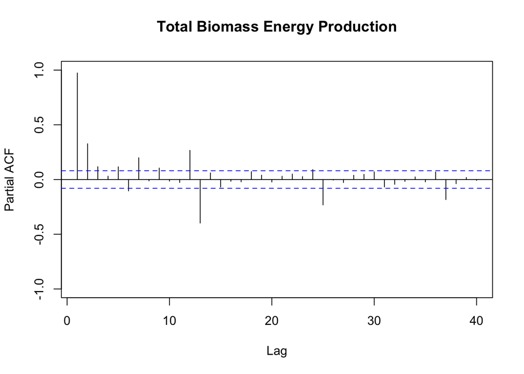

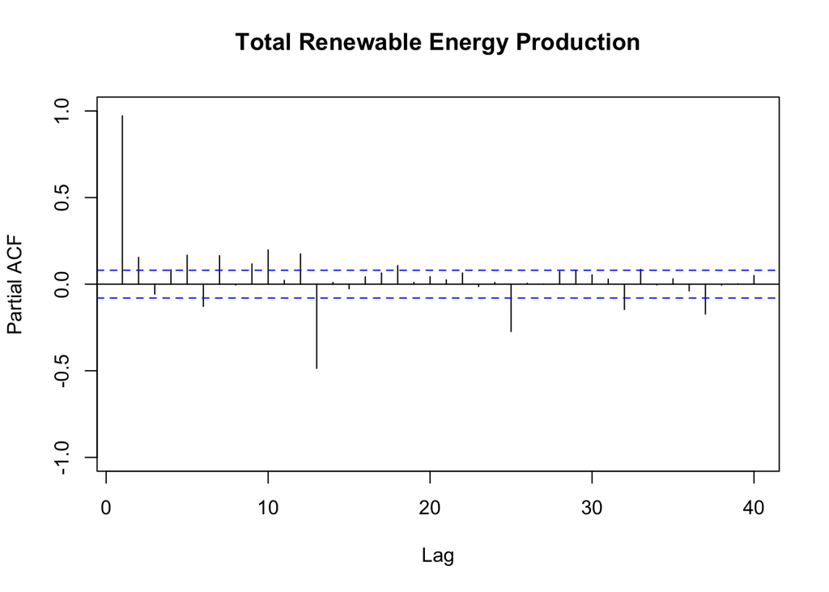

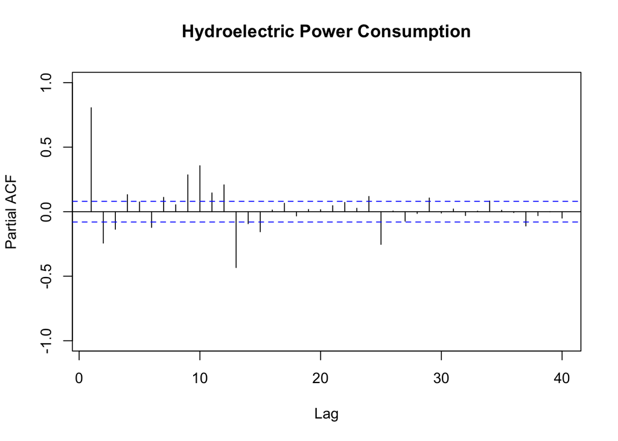

```r
for(i in 1:ndata){
  Pacf(energy_data2[,i],lag.max = 40,main=datanames[i],ylim=c(-1,1))
}
```